# 📘 Notebook 10: U-Net, Labelling Every Pixel

### Course: *From Papers to Practice: Landmark Deep Learning Architectures*

**Instructor:** Ioannis Tsioulis

*Paper: Ronneberger, Fischer and Brox (2015)*

> 💡 **This notebook is already run.** Every number and picture below was produced by the code above it, and each result is followed by a comment that explains what it shows. You can read it without running anything, or choose **Runtime → Run all** in Colab.

> ⏱️ **Training time and limitations.** Two small segmentation networks (with and without skip connections, about 120 thousand weights each) train for 800 steps on **synthetic** 64 × 64 images: about **six minutes** on a laptop processor, about a minute on a Colab GPU. The paper segmented cells in microscope images of 512 × 512 pixels with a network of 31 million weights and heavy elastic deformations as augmentation. We generate our own images (random shapes on a noisy, textured background) so that the notebook needs no download and the true answer is known for every pixel; the comparison between the two architectures, not the absolute numbers, is the point. Results vary slightly between runs.

## 🎯 Learning objectives

By the end of this notebook you will be able to:

- Explain **semantic segmentation**: a label for **every pixel**, not one label per image
- Explain the U-Net's **contracting path**, **expanding path** and **skip connections**
- Explain **transposed convolutions** for upsampling
- Train a U-Net and the same network **without skips**, and compare them with the **IoU** and **Dice** measures
- See where the difference lies: in **thin structures and boundaries**

> **Prerequisites:** [Notebook 02: LeNet-5](https://colab.research.google.com/github/giannis00/giannis00.github.io/blob/main/assets/jupyter/from-papers-to-practice/02_lenet5.ipynb) for convolutions and pooling, and [Notebook 04: ResNet](https://colab.research.google.com/github/giannis00/giannis00.github.io/blob/main/assets/jupyter/from-papers-to-practice/04_resnet.ipynb) for the idea of shortcut connections.

> 🔭 **Why this notebook matters:** U-Net was designed for medical images, where annotated examples are scarce, and it became the standard network for segmenting tumours, organs, cells, roads in satellite images and much more. It also has a second life: the denoising network inside diffusion image generators, including Stable Diffusion, is a U-Net (Notebook 12).

## 1. The paper

> 📄 O. Ronneberger, P. Fischer and T. Brox, [*U-Net: Convolutional Networks for Biomedical Image Segmentation*](https://arxiv.org/abs/1505.04597), MICCAI 2015.

> 📄 Its predecessor: J. Long, E. Shelhamer and T. Darrell, [*Fully Convolutional Networks for Semantic Segmentation*](https://arxiv.org/abs/1411.4038), CVPR 2015.

### Intuition first

A classifier (LeNet, AlexNet) shrinks the image step by step until one answer remains: *this is a cat*. **Segmentation** asks for a full-size answer: *these pixels are cell, those are background*. The network must understand **what** is in the image, which needs the large view that shrinking gives, and **where** exactly its edges are, which shrinking throws away.

U-Net solves both with a symmetric shape, drawn in the paper as a letter U:

1. a **contracting path** (left side of the U): convolutions and pooling, like a classifier, building understanding while the image shrinks;
2. an **expanding path** (right side): **transposed convolutions** that enlarge the feature maps back to full size;
3. **skip connections** across the U: at every level, the detailed feature maps of the contracting path are copied and **concatenated** to the expanding path, so precise locations lost by pooling come back.

Without the skips, the decoder must recreate fine detail from a tiny, blurry summary. With them, it can combine *what* (from the bottom of the U) with *where* (from the skips).

```python
import warnings
warnings.filterwarnings("ignore")

import time
import numpy as np
import matplotlib.pyplot as plt
import torch
import torch.nn as nn
import torch.nn.functional as F

torch.manual_seed(0)
torch.set_num_threads(4)
plt.rcParams["figure.dpi"] = 80
print("PyTorch", torch.__version__)
```

```
PyTorch 2.2.2+cpu
```

## 2. A synthetic segmentation task

Each image contains a few **discs**, **rectangles** and **thin lines** in random places, on a background with blobs of texture and noise. The target mask marks every pixel that belongs to a shape. The thin lines, one or two pixels wide, are deliberately included: they are the hardest test of fine detail.

```
train (2000, 1, 64, 64)  test (300, 1, 64, 64)  share of shape pixels: 0.1
```

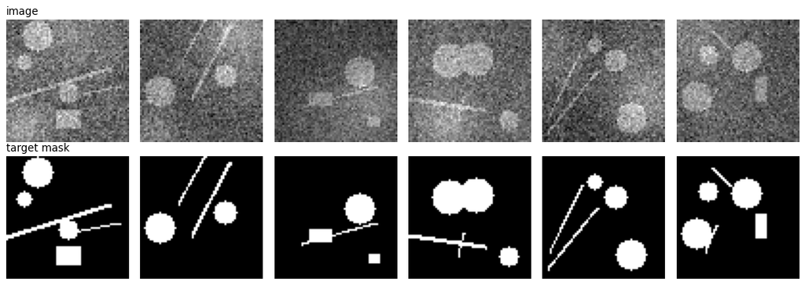

```python
SIZE = 64
yy, xx = np.mgrid[:SIZE, :SIZE]

def make_example(rng):
    mask = np.zeros((SIZE, SIZE), dtype=bool)
    for _ in range(rng.integers(1, 4)):                        # discs
        cy, cx, r = rng.integers(8, 56, 2).tolist() + [int(rng.integers(4, 10))]
        mask |= (yy - cy) ** 2 + (xx - cx) ** 2 <= r ** 2
    for _ in range(rng.integers(0, 3)):                        # rectangles
        y0, x0 = rng.integers(0, 52, 2); h, w = rng.integers(5, 14, 2)
        mask[y0:y0 + h, x0:x0 + w] = True
    for _ in range(rng.integers(1, 3)):                        # thin lines
        y0, x0, y1, x1 = rng.integers(0, SIZE, 4)
        t = np.linspace(0, 1, 120)
        ly, lx = (y0 + t * (y1 - y0)).astype(int), (x0 + t * (x1 - x0)).astype(int)
        mask[ly, lx] = True
        if rng.random() < 0.5:
            mask[np.clip(ly + 1, 0, SIZE - 1), lx] = True
    background = sum(rng.random() * np.exp(-((yy - rng.integers(0, SIZE)) ** 2 + (xx - rng.integers(0, SIZE)) ** 2) / (2 * rng.integers(6, 20) ** 2))
                     for _ in range(4))
    image = 0.6 * mask + 0.5 * background + rng.normal(0, 0.25, (SIZE, SIZE))
    return image.astype(np.float32), mask.astype(np.float32)

def make_set(n, seed):
    rng = np.random.default_rng(seed)
    images, masks = zip(*(make_example(rng) for _ in range(n)))
    return torch.tensor(np.stack(images))[:, None], torch.tensor(np.stack(masks))[:, None]

X_train, M_train = make_set(2000, seed=0)
X_test, M_test = make_set(300, seed=1)
print("train", tuple(X_train.shape), " test", tuple(X_test.shape), " share of shape pixels:", round(M_train.mean().item(), 3))

fig, axes = plt.subplots(2, 6, figsize=(13, 4.6))
for i in range(6):
    axes[0, i].imshow(X_train[i, 0], cmap="gray"); axes[0, i].axis("off")
    axes[1, i].imshow(M_train[i, 0], cmap="gray"); axes[1, i].axis("off")
axes[0, 0].set_title("image", loc="left"); axes[1, 0].set_title("target mask", loc="left")
plt.tight_layout()
plt.show()
```

**What we see.** 2,000 training and 300 test images; only about **10%** of all pixels belong to a shape. The shapes are visible to the eye but far from clean: textured, uneven backgrounds and strong pixel noise blur their edges, and the thin lines are barely brighter than the noise around them. The target masks are perfectly sharp, so the network must decide, pixel by pixel, where the true edge lies.

## 3. U-Net, and the same network without skips

Both networks have the same contracting and expanding paths: three levels (64, 32 and 16 pixels wide), a bottleneck at 8 × 8, and transposed convolutions to come back up. The only difference is whether the decoder receives the concatenated skip features. To keep the comparison fair, the network without skips gets the same number of channels in its decoder.

```python
def double_conv(cin, cout):
    return nn.Sequential(nn.Conv2d(cin, cout, 3, padding=1), nn.BatchNorm2d(cout), nn.ReLU(),
                         nn.Conv2d(cout, cout, 3, padding=1), nn.BatchNorm2d(cout), nn.ReLU())

class SegNet(nn.Module):
    def __init__(self, skips, c=8):
        super().__init__()
        self.skips = skips
        self.down1, self.down2, self.down3 = double_conv(1, c), double_conv(c, 2 * c), double_conv(2 * c, 4 * c)
        self.bottom = double_conv(4 * c, 8 * c)
        self.up3, self.up2, self.up1 = (nn.ConvTranspose2d(8 * c, 4 * c, 2, stride=2),
                                        nn.ConvTranspose2d(4 * c, 2 * c, 2, stride=2),
                                        nn.ConvTranspose2d(2 * c, c, 2, stride=2))
        k = 2 if skips else 1
        self.dec3, self.dec2, self.dec1 = double_conv(k * 4 * c, 4 * c), double_conv(k * 2 * c, 2 * c), double_conv(k * c, c)
        self.head = nn.Conv2d(c, 1, 1)

    def forward(self, x):
        d1 = self.down1(x)                       # 64 x 64
        d2 = self.down2(F.max_pool2d(d1, 2))     # 32 x 32
        d3 = self.down3(F.max_pool2d(d2, 2))     # 16 x 16
        b = self.bottom(F.max_pool2d(d3, 2))     # 8 x 8: the bottom of the U
        u3 = self.up3(b)
        u3 = self.dec3(torch.cat([u3, d3], 1) if self.skips else u3)
        u2 = self.up2(u3)
        u2 = self.dec2(torch.cat([u2, d2], 1) if self.skips else u2)
        u1 = self.up1(u2)
        u1 = self.dec1(torch.cat([u1, d1], 1) if self.skips else u1)
        return self.head(u1)                     # one score per pixel

count = lambda m: sum(p.numel() for p in m.parameters())
print("U-Net weights:", f"{count(SegNet(True)):,}", "   without skips:", f"{count(SegNet(False)):,}")
print("output shape for one image:", tuple(SegNet(True)(X_train[:1]).shape))
```

```
U-Net weights: 121,385    without skips: 109,289
output shape for one image: (1, 1, 64, 64)
```

**What we see.** The output has exactly the size of the input, one score per pixel. The two networks are almost the same size: **121,385** weights with skips and **109,289** without; the difference is only that the decoder layers of the U-Net receive twice as many channels (their own plus the skip's). Any difference in quality comes from the skips, not from a bigger model.

## 4. Training and measuring overlap

Accuracy per pixel is misleading here: most pixels are background, and predicting "background everywhere" would already be right about **90%** of the time. Segmentation is measured by **overlap** between the predicted and the true shape:

- **IoU** (intersection over union): pixels in both, divided by pixels in either;
- **Dice**: twice the intersection, divided by the total size of both (used in the U-Net paper's field, medical imaging).

```python
def train(skips, steps=800, batch=16):
    torch.manual_seed(0)
    model = SegNet(skips)
    opt = torch.optim.Adam(model.parameters(), lr=1e-3)
    start = time.time()
    for step in range(steps):
        idx = torch.randint(0, len(X_train), (batch,))
        loss = F.binary_cross_entropy_with_logits(model(X_train[idx]), M_train[idx])
        opt.zero_grad(); loss.backward(); opt.step()
    print(f"{'U-Net (with skips)' if skips else 'without skips':20s} trained in {time.time() - start:.0f} s")
    return model.eval()

def scores(model, X, M):
    with torch.no_grad():
        pred = torch.cat([model(X[i:i + 100]) for i in range(0, len(X), 100)]) > 0
    truth = M > 0.5
    inter = (pred & truth).sum().item(); union = (pred | truth).sum().item()
    return {"pixel accuracy": (pred == truth).float().mean().item(), "IoU": inter / union,
            "Dice": 2 * inter / (pred.sum().item() + truth.sum().item())}

unet = train(True)
plain = train(False)
import pandas as pd
print("predicting background everywhere: pixel accuracy", round(1 - M_test.mean().item(), 3), ", IoU 0")
pd.DataFrame({"U-Net (with skips)": scores(unet, X_test, M_test), "without skips": scores(plain, X_test, M_test)}).T.round(3)
```

```
U-Net (with skips)   trained in 234 s
```

```
without skips        trained in 137 s
```

```
predicting background everywhere: pixel accuracy 0.897 , IoU 0
```

|  | pixel accuracy | IoU | Dice |
| --- | --- | --- | --- |
| U-Net (with skips) | 0.993 | 0.938 | 0.968 |
| without skips | 0.982 | 0.837 | 0.911 |

**What we see.** Predicting "background" everywhere already gives **89.7%** pixel accuracy and an IoU of 0, which is why pixel accuracy is the wrong measure here. On the measures that matter:

- **U-Net:** IoU **0.938**, Dice **0.968**.
- **Without skips:** IoU **0.837**, Dice **0.911**.

The skips cut the non-overlapping area by more than half (from about 16% of the shapes to about 6%). Both networks reach high pixel accuracy (98% and 99%), which hides this difference almost completely.

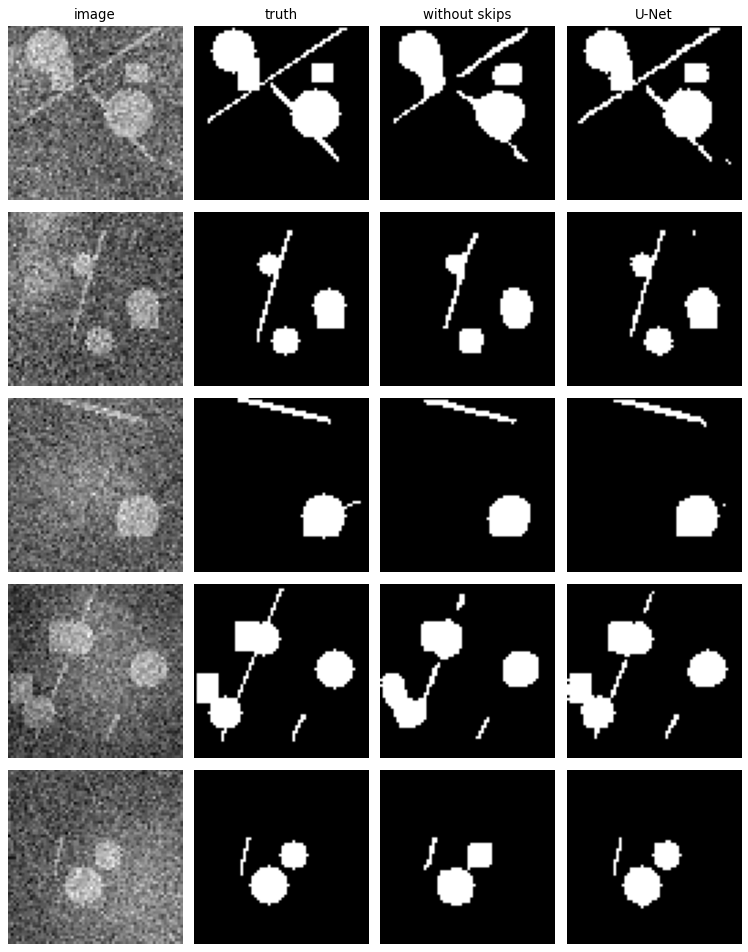

```python
with torch.no_grad():
    p_unet = (unet(X_test[:5]) > 0).float()
    p_plain = (plain(X_test[:5]) > 0).float()
fig, axes = plt.subplots(5, 4, figsize=(9.5, 12))
for i in range(5):
    for j, (img, name) in enumerate([(X_test[i, 0], "image"), (M_test[i, 0], "truth"), (p_plain[i, 0], "without skips"), (p_unet[i, 0], "U-Net")]):
        axes[i, j].imshow(img, cmap="gray"); axes[i, j].axis("off")
        if i == 0:
            axes[i, j].set_title(name)
plt.tight_layout()
plt.show()
```

**What we see.** The pictures show **where** the network without skips fails. It finds every object, so it understands *what* is in the image, but its shapes are **blobby**: discs and rectangles merge into rounded lumps, corners are rounded off, and thin lines become broken or thickened fragments. Its decoder has to repaint the details from an 8 × 8 summary. The U-Net's masks follow the true outlines closely, keep the rectangles' corners and draw the thin lines almost unbroken, because the skips hand the decoder the full-resolution features.

## 5. Where exactly is the difference? Edges and thin lines

We measure accuracy only on the **difficult pixels**: those within 1 pixel of a boundary between shape and background.

```python
def boundary_pixels(M):
    m = M[:, 0] > 0.5
    eroded = -F.max_pool2d(-M.float(), 3, stride=1, padding=1)[:, 0] > 0.5
    dilated = F.max_pool2d(M.float(), 3, stride=1, padding=1)[:, 0] > 0.5
    return dilated & ~eroded

edge = boundary_pixels(M_test)
truth = M_test[:, 0] > 0.5
for name, model in [("U-Net (with skips)", unet), ("without skips", plain)]:
    with torch.no_grad():
        pred = torch.cat([model(X_test[i:i + 100]) for i in range(0, 300, 100)])[:, 0] > 0
    print(f"{name:20s} accuracy on boundary pixels: {(pred[edge] == truth[edge]).float().mean().item():.3f}"
          f"   elsewhere: {(pred[~edge] == truth[~edge]).float().mean().item():.3f}")
print("share of pixels that are boundary pixels:", round(edge.float().mean().item(), 3))
```

```
U-Net (with skips)   accuracy on boundary pixels: 0.940   elsewhere: 1.000
```

```
without skips        accuracy on boundary pixels: 0.836   elsewhere: 1.000
share of pixels that are boundary pixels: 0.108
```

**What we see.** This makes the picture exact. About **11%** of all pixels lie within one pixel of a boundary (including every pixel of the thin lines). On all the **other** pixels both networks are essentially perfect (accuracy **1.000**). The entire difference is concentrated at the boundaries: **94.0%** correct for the U-Net against **83.6%** without skips. Knowing *what* is in the image is easy for both; knowing exactly *where* its edges lie is what the skip connections provide.

## ⚠️ Common pitfalls

- **Judging segmentation by pixel accuracy.** When most pixels are background, a useless model scores high. Use IoU or Dice.
- **Mismatched sizes when concatenating skips.** Pooling and upsampling must bring the maps back to exactly the same size; odd image sizes break this. (The paper used unpadded convolutions and cropped the skips; we pad, so sizes match.)
- **Concatenating vs adding.** U-Net **concatenates** skip features (the decoder chooses how to combine them); ResNet **adds** them. Both are "skip connections", with different roles.
- **Testing on images like the training ones only.** Real segmentation fails on new scanners, lighting or staining; augmentation and diverse data matter more than architecture.
- **Forgetting class imbalance in the loss.** With tiny objects, a weighted loss or a Dice loss often trains better than plain cross-entropy.

## ✏️ Exercises

### Exercise 1 (Dice loss)

Train the U-Net with the **Dice loss**, $1 - \frac{2 \sum p\,t}{\sum p + \sum t}$ on the predicted probabilities, instead of binary cross-entropy, for 600 steps. Compare IoU on the test set.

```python
# Your solution here:
```

**💡 Show solution**

```
def dice_loss(logits, target):
    p = torch.sigmoid(logits)
    return 1 - (2 * (p * target).sum() + 1) / (p.sum() + target.sum() + 1)

torch.manual_seed(0)
dice_net = SegNet(True)
opt = torch.optim.Adam(dice_net.parameters(), lr=1e-3)
for step in range(600):
    idx = torch.randint(0, len(X_train), (16,))
    loss = dice_loss(dice_net(X_train[idx]), M_train[idx])
    opt.zero_grad(); loss.backward(); opt.step()
print({k: round(v, 3) for k, v in scores(dice_net.eval(), X_test, M_test).items()})
```

*The Dice loss optimises overlap directly and is not dominated by the many easy background pixels. With balanced data the two losses end up close; with tiny targets (a small tumour in a large scan) Dice or a combination of both often wins.*

### Exercise 2 (How few examples?)

The paper's selling point was learning from very few annotated images. Train the U-Net on only the first **50** training images (800 steps) and measure IoU. How much is lost compared with 2,000 images?

```python
# Your solution here:
```

**💡 Show solution**

```
torch.manual_seed(0)
few = SegNet(True)
opt = torch.optim.Adam(few.parameters(), lr=1e-3)
for step in range(800):
    idx = torch.randint(0, 50, (16,))
    loss = F.binary_cross_entropy_with_logits(few(X_train[idx]), M_train[idx])
    opt.zero_grad(); loss.backward(); opt.step()
print("IoU with 50 images:", round(scores(few.eval(), X_test, M_test)["IoU"], 3))
```

*Even 50 examples give a usable segmentation, because every image contains thousands of labelled pixels and the convolutions share what they learn across positions. This is why U-Net worked in medicine, where each annotated scan is expensive.*

### Exercise 3 (Which skip matters most?)

Build U-Nets that keep only **one** of the three skips (set the other two to zeros of the right shape before concatenating) and train each for 600 steps. Which level's skip contributes most to the boundary accuracy?

```python
# Your solution here:
```

**💡 Show solution**

```
class OneSkip(SegNet):
    def __init__(self, keep):
        super().__init__(True)
        self.keep = keep
    def forward(self, x):
        d1 = self.down1(x); d2 = self.down2(F.max_pool2d(d1, 2)); d3 = self.down3(F.max_pool2d(d2, 2))
        b = self.bottom(F.max_pool2d(d3, 2))
        s = {1: d1, 2: d2, 3: d3}
        s = {k: (v if k == self.keep else torch.zeros_like(v)) for k, v in s.items()}
        u3 = self.dec3(torch.cat([self.up3(b), s[3]], 1))
        u2 = self.dec2(torch.cat([self.up2(u3), s[2]], 1))
        return self.head(self.dec1(torch.cat([self.up1(u2), s[1]], 1)))

for keep in [1, 2, 3]:
    torch.manual_seed(0)
    m = OneSkip(keep)
    opt = torch.optim.Adam(m.parameters(), lr=1e-3)
    for step in range(600):
        idx = torch.randint(0, len(X_train), (16,))
        loss = F.binary_cross_entropy_with_logits(m(X_train[idx]), M_train[idx])
        opt.zero_grad(); loss.backward(); opt.step()
    m.eval()
    with torch.no_grad():
        pred = torch.cat([m(X_test[i:i + 100]) for i in range(0, 300, 100)])[:, 0] > 0
    print(f"only skip {keep}: boundary accuracy {(pred[edge] == truth[edge]).float().mean().item():.3f}")
```

*The skip at the **full resolution** (level 1) usually matters most for boundaries and thin lines, because it carries the exact pixel positions; the deeper skips carry coarser context.*

## 🔑 Key takeaways

- **Segmentation** gives a label to every pixel and needs both **context** (what) and **detail** (where).
- U-Net's **contracting path** builds context, its **expanding path** restores size, and its **skip connections** bring back the detail lost by pooling.
- Measure segmentation with **IoU** or **Dice**, never with plain pixel accuracy.
- The benefit of skips is concentrated at **boundaries and thin structures**.
- U-Net learns from **few** annotated images and became the backbone of medical segmentation and of diffusion models.

**Next:** *Notebook 11: Vision Transformer*, where an image is cut into patches and read like a sentence by a Transformer, with no convolutions at all.

*© Ioannis Tsioulis. *From Papers to Practice: Landmark Deep Learning Architectures*. Prepared for educational use.*